# Боль в фасеточных (межпозвонковых) суставах после операции на позвоночнике

2020-01-16T12:00:00Z

Позвоночник - костно-суставной комплекс, который служит для поддержания оси тела и защиты спинного мозга. Спинной мозг представляет собой сплетение проводящих путей с переключателями, которое передает команды от головного мозга ко всем мышцам тела.

Позвоночный столб в целом прямой, если рассматривать спереди или сзади. У некоторых людей, однако, могут быть небольшие боковые изгибы, которые остаются в физиологических пределах.

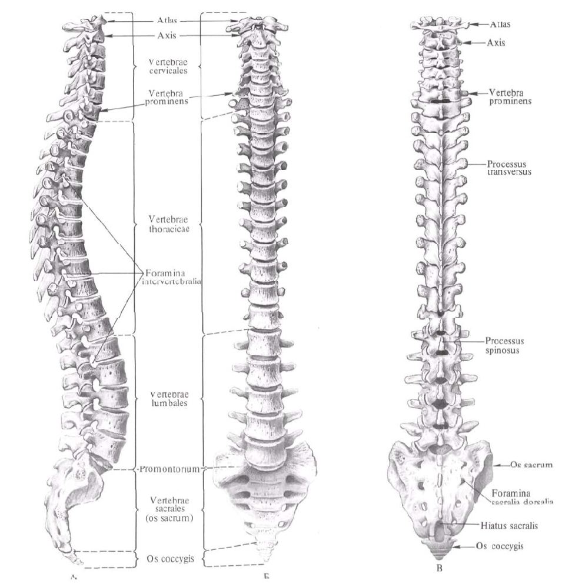

*Позвоночный столб. А - вид справа. Б - вид спереди. В - вид сзади (Синельников Р.Д., Синельников Я.Р. Атлас анатомии человека).*

С другой стороны, в сагиттальной плоскости позвоночный столб имеет следующие четыре изгиба: шейный лордоз, грудной кифоз, поясничный лордоз и крестцово-копчиковый изгиб.

Обычно, когда человек стоит, задняя часть головы, спина и ягодицы лежат параллельно вертикальной плоскости, например стене. Степень этих изгибов показывается определенными линиями, о чем будет сказано позже.

Позвоночник состоит из 33-34 позвонков, обычно подразделяемых на пять отделов: шейный, грудной, поясничный, крестцовый и копчиковый. Существует 7 (редко 8) шейных, 12 грудных, 5 (редко 6) поясничных, 5 крестцовых и 4 копчиковых позвонка.

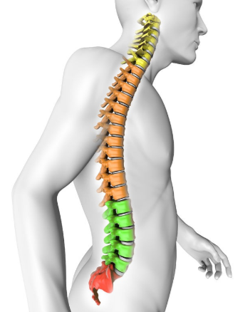

*Отделы позвоночника (spineuniverse.com)*

Крестцовые и копчиковые позвонки обычно объединяются и образуют крестец и копчик соответственно. Позвонки в каждом отделе имеют сходное строение с некоторыми отличиями.

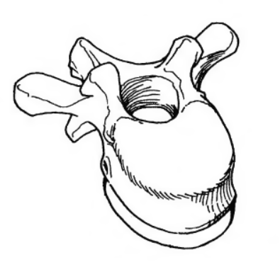

*Грудной позвонок (Альберт Т.Д., Ваккаро А.Р. Физикальное обследование позвоночника)*

Позвонок состоит из тела, остистого отростка, двух поперечных отростков, двух ножек и дуги. Двумя основными исключениями являются С1 и C2 позвонки.

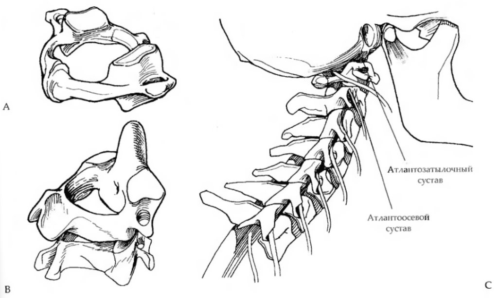

*Шейные позвонки. A - атлант (1-ый шейный позвонок), B - аксис (2-ый шейный позвонок), С - кранио-вертебральный отдел (Альберт Т.Д., Ваккаро А.Р. Физикальное обследование позвоночника)*

Первый шейный позвонок (C1) называется “атлант” и не имеет тела позвонка. Атлант образует атлантозатылочное сочленение с затылочной костью черепа и способствует нормальному сгибанию и выпрямлению шеи. Второй шейный позвонок называется “аксис”. На верхней части тела позвонка С2 имеется костный выступ, называемый зубом или зубовидным отростком, который входит в позвоночное отверстие атланта. Атлант вместе с аксисом образуют атлантоаксиальное (атлантоосевое) сочленение, которое обеспечивает основной обьем вращения в шее.

Соседние тела позвонков между C2 и S1 отделяются друг от друга межпозвоночными дисками, состоящими из волокнистого соединительно-тканного хряща, действующего как своеобразный “буфер” против возможных механических ударов и сотрясений.

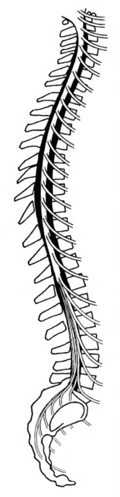

*Взаиморасположение позвоночника, спинного мозга и спинномозговых нервов (Альберт Т.Д., Ваккаро А.Р. Физикальное обследование позвоночника)*

Спинной мозг находится в позвоночном канале на протяжении от С1 до его конца (конус спинного мозга), который находится на уровне между L1 и L2. Терминальная нить тянется от конуса спинного мозга и соединяется с копчиком. Спинной мозг делится на сегменты, и от каждого сегмента спинного мозга отходит одна из 31 пар корешков, которые образуют спинномозговые нервы. Существует 8 пар шейных, 12 пар грудных, 5 пар поясничных и 5 пар крестцовых спинномозговых нервов, а также одна пара копчиковых. Спинномозговые нервы выходят из позвоночника через межпозвоночные отверстия. Каждый спинномозговой нерв отвечает за определенный участок тела, обеспечивает двигательную и чувствительную иннервацию.